# Quast Analysis for trim testing

Håkon Kaspersen

2018-08-20

```r
report_loc <- "D:/R_Data/Quast/transposed_report.tsv"
```

```r
# Creates a data frame for plotting from Quast data
create_df <- function(df) {
  df <- df %>%
  rename(ctg_0_bp = X..contigs.....0.bp.,
         ctg_1000_bp = X..contigs.....1000.bp.,
         ctg_5000_bp = X..contigs.....5000.bp.,
         ctg_10000_bp = X..contigs.....10000.bp.,
         ctg_25000_bp = X..contigs.....25000.bp.,
         ctg_50000_bp = X..contigs.....50000.bp.,
         tot_len_0_bp = Total.length.....0.bp.,
         tot_len_1000_bp = Total.length.....1000.bp.,
         tot_len_5000_bp = Total.length.....5000.bp.,
         tot_len_10000_bp = Total.length.....10000.bp.,
         tot_len_25000_bp = Total.length.....25000.bp.,
         tot_len_50000_bp = Total.length.....50000.bp.,
         no_of_contigs = X..contigs,
         no_of_misassemblies = X..misassemblies,
         no_of_misassembled_ctg = X..misassembled.contigs,
         no_of_local_misassemblies = X..local.misassemblies,
         unaligned_contigs = X..unaligned.contigs,
         N_per_100kbp = X..N.s.per.100.kbp,
         mismatches_per_100kbp = X..mismatches.per.100.kbp,
         indels_per_100kbp = X..indels.per.100.kbp,
         no_of_genes = X..genes) %>%
  mutate(type = ifelse(grepl("_broken", Assembly) == TRUE, "Broken", "Normal"),
         seq = ifelse(grepl("hiseq_flex", Assembly) == TRUE, "hiseq_flex_150bp",
               ifelse(grepl("hiseqr_xt", Assembly) == TRUE, "hiseqr_xt_250bp", "hiseq_xt_125bp")),
         test = gsub("(.*?)_test.+", "\\1", Assembly))
  return(df)
}

# Present summary of data
summary_data <- function(df) {
  df <- df %>%
  select(seq,
         test,
         type,
         no_of_contigs,
         Largest.contig,
         Total.length,
         N50,
         GC....,
         no_of_misassembled_ctg,
         N_per_100kbp,
         Duplication.ratio) %>%
  group_by(seq, test, type) %>%
  summarise_all(funs(mean(.))) %>%
  rename(`GC%` = GC....,
         "Number of contigs" = no_of_contigs,
         "Largest contig" = Largest.contig,
         "Total length" = Total.length,
         "Number of misassembled contigs" = no_of_misassembled_ctg,
         "N per 100 kbp" = N_per_100kbp,
         "Duplication ratio" = Duplication.ratio,
         "Method" = seq,
         "Trim setting" = test,
         "Type" = type)
  return(df)
}
```

```r
raw_df <- read.delim(report_loc,
                         sep = "\t",
                         header = TRUE,
                         stringsAsFactors = F)

clean_df <- create_df(raw_df)
```

## 0.1 Plotting

### 0.1.1 Number of contigs

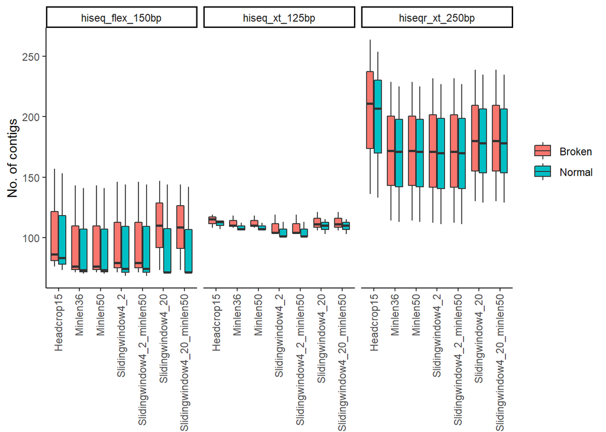

```r
ggplot(clean_df, aes(test, no_of_contigs, fill = type)) +
  geom_boxplot() +
  theme_classic() +
  theme(axis.text.x = element_text(angle = 90, hjust = 1, vjust = 0.4)) +
  labs(y = "No. of contigs",
       x = NULL,
       fill = NULL) +
  facet_wrap(~ seq)
```

### 0.1.2 N50

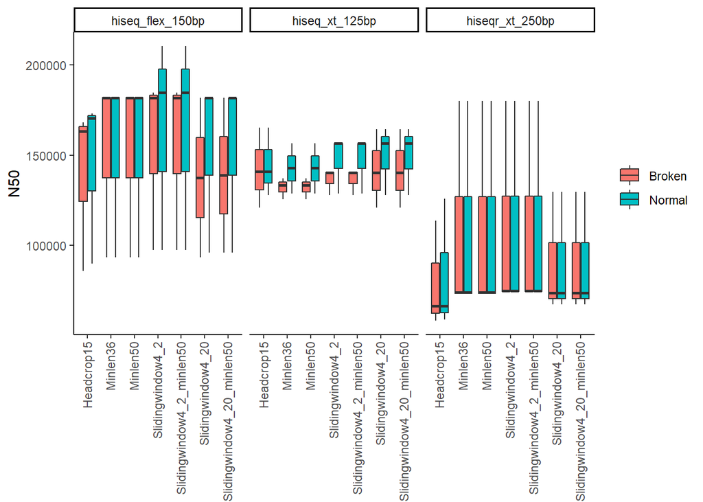

```r
ggplot(clean_df, aes(test, N50, fill = type)) +
  geom_boxplot() +
  theme_classic() +
  theme(axis.text.x = element_text(angle = 90, hjust = 1, vjust = 0.4)) +
  labs(y = "N50",
       x = NULL,
       fill = NULL) +
  facet_wrap(~ seq, nrow = 1)
```

### 0.1.3 Number of misassembled contigs

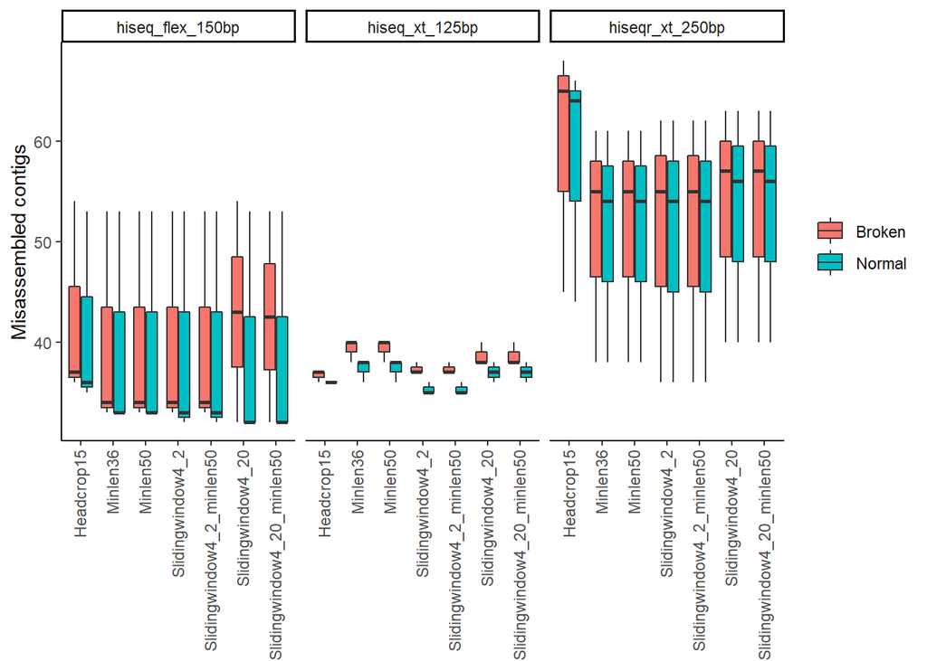

```r
ggplot(clean_df, aes(test, no_of_misassembled_ctg, fill = type)) +
  geom_boxplot() +
  theme_classic() +
  theme(axis.text.x = element_text(angle = 90, hjust = 1, vjust = 0.4)) +
  labs(y = "Misassembled contigs",
       x = NULL,
       fill = NULL) +
  facet_wrap(~ seq, nrow = 1)
```

### 0.1.4 Number of contigs per size

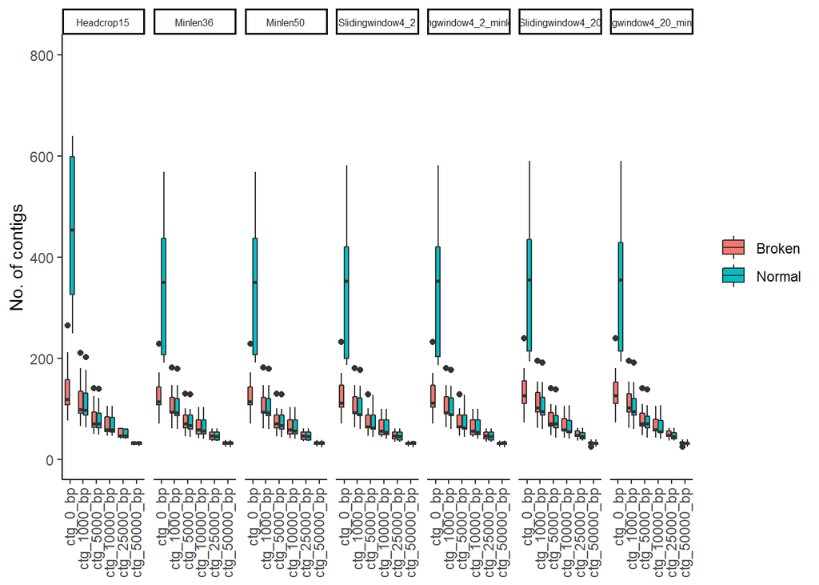

```r
clean_df %>%
  gather(key,
         value,
         c(ctg_0_bp,
             ctg_1000_bp,
             ctg_5000_bp,
             ctg_10000_bp,
             ctg_25000_bp,
             ctg_50000_bp)) %>%
  mutate(key = factor(key, ordered = TRUE, levels = c("ctg_0_bp",
                                                      "ctg_1000_bp",
                                                      "ctg_5000_bp",
                                                      "ctg_10000_bp",
                                                      "ctg_25000_bp",
                                                      "ctg_50000_bp"))) %>%
  ggplot(aes(key, value, fill = type)) +
  geom_boxplot() +
  scale_y_continuous(limits = c(0, 800)) +
  theme_classic() +
  theme(axis.text.x = element_text(angle = 90, hjust = 1, vjust = 0.4),
        axis.title.x = element_blank(),
        strip.text = element_text(size = 6)) +
  labs(y = "No. of contigs",
       fill = NULL) +
  facet_wrap(~test, nrow = 1)
```

## 0.2 Summary data

```r
summary_df <- summary_data(clean_df)

summary_df
```

| Method | Trim setting | Type | Number of contigs | Largest contig | Total length | N50 | GC% | Number of misassembled contigs | N per 100 kbp | Duplication ratio |
| --- | --- | --- | --- | --- | --- | --- | --- | --- | --- | --- |
| hiseq_flex_150bp | Headcrop15 | Broken | 106.33333 | 358177.0 | 4982738 | 139002.33 | 50.61333 | 42.33333 | 1.6433333 | 1.147333 |
| hiseq_flex_150bp | Headcrop15 | Normal | 103.00000 | 358177.0 | 4983045 | 144536.00 | 50.61333 | 41.33333 | 7.7500000 | 1.151667 |
| hiseq_flex_150bp | Minlen36 | Broken | 96.66667 | 393795.0 | 4998774 | 152418.33 | 50.62000 | 40.00000 | 1.0866667 | 1.156667 |
| hiseq_flex_150bp | Minlen36 | Normal | 94.66667 | 393795.0 | 4999009 | 152418.33 | 50.62000 | 39.66667 | 5.7700000 | 1.156667 |
| hiseq_flex_150bp | Minlen50 | Broken | 96.66667 | 393795.0 | 4998719 | 152418.33 | 50.62000 | 40.00000 | 1.1000000 | 1.156667 |
| hiseq_flex_150bp | Minlen50 | Normal | 94.66667 | 393795.0 | 4998952 | 152418.33 | 50.62000 | 39.66667 | 5.7466667 | 1.156667 |
| hiseq_flex_150bp | Slidingwindow4_2 | Broken | 98.66667 | 362453.7 | 5000112 | 154633.33 | 50.62333 | 40.00000 | 1.3033333 | 1.155000 |
| hiseq_flex_150bp | Slidingwindow4_2 | Normal | 95.33333 | 362453.7 | 5000428 | 164196.67 | 50.62333 | 39.33333 | 7.6100000 | 1.155000 |
| hiseq_flex_150bp | Slidingwindow4_2_minlen50 | Broken | 98.66667 | 362453.7 | 5000112 | 154633.33 | 50.62333 | 40.00000 | 1.3033333 | 1.155000 |
| hiseq_flex_150bp | Slidingwindow4_2_minlen50 | Normal | 95.33333 | 362453.7 | 5000428 | 164196.67 | 50.62333 | 39.33333 | 7.6100000 | 1.155000 |

[output cut: 32 more lines]